# Canadian homicide rates

15 September 2026

This is a joint example of (1) rearranging data and (2) graphing data.

## Rearranging data

## Read data in wide format and play with it

Data are originally from [here](http://www.statcan.gc.ca/tables-tableaux/sum-som/l01/cst01/legal12b-eng.htm) (it might be possible to *scrape* this data set using the `XML` package …).

I also got [data on population size in 2011 from Wikipedia](http://en.wikipedia.org/wiki/List_of_Canadian_provinces_and_territories_by_population) .

Read data (from two separate files).

```r
library(tidyverse)
## using col_types=cols() suppresses the messages about which type is which
dat <- read_csv("../docs/data/CA_homicide.csv", col_types=cols())
popdat <- read_csv("../docs/data/CA_popdat.csv", col_types=cols())
```

These data are in wide format:

```r
head(dat)
```

```
## # A tibble: 6 × 6
##   Place                     `2007` `2008` `2009` `2010` `2011`
##   <chr>                      <dbl>  <dbl>  <dbl>  <dbl>  <dbl>
## 1 Canada                      1.8    1.83   1.81   1.62   1.73
## 2 Newfoundland and Labrador   0.59   0.99   0.2    0.78   0.78
## 3 Prince Edward Island        0      1.43   0      0      0.69
## 4 Nova Scotia                 1.39   1.28   1.6    2.22   2.33
## 5 New Brunswick               1.07   0.4    1.6    1.2    1.06
## 6 Quebec                      1.17   1.19   1.12   1.06   1.32
```

Note that `read_csv()` has **not** modified the column names to make them legal R variables names (`read.csv()` will do that by default: use `check.names=FALSE` to suppress this)

What if we want combine other information?

```r
rdat <- tibble(Place=dat$Place,
      Region=c("all",rep("Atlantic",4),
               rep("East",2),
               rep("West",4),
               rep("North",3)))
head(rdat)
```

```
## # A tibble: 6 × 2
##   Place                     Region
##   <chr>                     <chr>
## 1 Canada                    all
## 2 Newfoundland and Labrador Atlantic
## 3 Prince Edward Island      Atlantic
## 4 Nova Scotia               Atlantic
## 5 New Brunswick             Atlantic
## 6 Quebec                    East
```

Let’s start by converting the data to long form:

```r
sdat <- (dat
    %>% pivot_longer(names_to="year",values_to="homicides",-Place,
                     names_transform=list(year=as.numeric))
)
head(sdat)
```

```
## # A tibble: 6 × 3
##   Place                      year homicides
##   <chr>                     <dbl>     <dbl>
## 1 Canada                     2007      1.8
## 2 Canada                     2008      1.83
## 3 Canada                     2009      1.81
## 4 Canada                     2010      1.62
## 5 Canada                     2011      1.73
## 6 Newfoundland and Labrador  2007      0.59
```

(we use `names_transform` to convert the years back to numeric values)

Now combine all three data sets (`full_join` will automatically match all columns with identical names across the data sets, but it’s better practice to specify the matching columns explicitly).

```r
sdat2 <- sdat %>%
    full_join(rdat,by="Place") %>%
    full_join(popdat,by="Place")
```

```r
dmat <- as.matrix(dat[,-1])
rownames(dmat) <- dat$Place
rowMeans(dmat)  ## means by place
```

```
##                    Canada Newfoundland and Labrador      Prince Edward Island
##                     1.758                     0.668                     0.424
##               Nova Scotia             New Brunswick                    Quebec
##                     1.764                     1.066                     1.172
##                   Ontario                  Manitoba              Saskatchewan
##                     1.386                     4.432                     3.262
##                   Alberta          British Columbia                     Yukon
##                     2.622                     2.218                     4.806
##     Northwest Territories                   Nunavut
##                     5.038                    18.584
```

```r
colMeans(dmat)  ## means by year
```

```
##     2007     2008     2009     2010     2011
## 3.812143 3.587857 3.588571 3.040000 3.542857
```

(Don’t forget the `na.rm` argument, unnecessary in this case, that can be provided to most R summary functions to get them to ignore `NA` values.)

If we want summary statistics from the full data set we can do

```r
sdat2 %>%
    group_by(Place) %>%
    summarise(homicides=mean(homicides))
## fancier
sdat2 %>%
    group_by(year) %>%
    summarise(across(homicides,list(mean=mean,sd=sd)))
```

[output not shown]

One more useful technique is reordering factors (representing categorical variables) in a sensible way. Right now the ‘places’ (provinces, territories, etc.) are ordered alphabetically, R’s default.

```r
sdat3 <- sdat2 %>%
    mutate(Place=forcats::fct_reorder(Place,Pop_2011))
## equivalent
sdat3 <- sdat2 %>%
    mutate(across(Place,~forcats::fct_reorder(.,Pop_2011)))
```

This will be useful in the future, but is different from the **order the data frame is stored in**, which we can modify via `arrange()` (use `desc(Pop_2011)` to arrange in descending order of population):

```r
(sdat3
    %>% arrange(desc(Pop_2011))
    %>% head()
)
```

```
## # A tibble: 6 × 5
##   Place    year homicides Region Pop_2011
##   <fct>   <dbl>     <dbl> <chr>     <dbl>
## 1 Canada   2007      1.8  all    33476688
## 2 Canada   2008      1.83 all    33476688
## 3 Canada   2009      1.81 all    33476688
## 4 Canada   2010      1.62 all    33476688
## 5 Canada   2011      1.73 all    33476688
## 6 Ontario  2007      1.58 East   12851821
```

I can also summarise by combinations of variables:

```r
sdat3 %>% group_by(year,Region) %>%
    summarise(across(homicides,mean),.groups="drop")
```

```
## # A tibble: 25 × 3
##     year Region   homicides
##    <dbl> <chr>        <dbl>
##  1  2007 Atlantic     0.762
##  2  2007 East         1.38
##  3  2007 North       11.0
##  4  2007 West         3.16
##  5  2007 all          1.8
##  6  2008 Atlantic     1.02
##  7  2008 East         1.27
##  8  2008 North        9.53
##  9  2008 West         3.29
## 10  2008 all          1.83
## # ℹ 15 more rows
```

What if I want the mean and standard error? R doesn’t have a built-in “standard error of the mean” function so I define one when I need it:

```r
sem <- function(x) { sd(x)/sqrt(length(x)) }
region_avgs <- sdat3 %>% group_by(year,Region) %>%
    summarise(across(homicides,list(mean=~mean(.,na.rm=TRUE),
                                    sem=sem)),
              .groups="drop")
head(region_avgs)
```

```
## # A tibble: 6 × 4
##    year Region   homicides_mean homicides_sem
##   <dbl> <chr>             <dbl>         <dbl>
## 1  2007 Atlantic          0.762         0.303
## 2  2007 East              1.38          0.205
## 3  2007 North            11.0           5.69
## 4  2007 West              3.16          0.677
## 5  2007 all               1.8          NA
## 6  2008 Atlantic          1.02          0.227
```

**Question: why do I have NA values?**

Drilling down to check some values:

```r
sdat3 %>% filter(year==2007 & Region=="all")
```

```
## # A tibble: 1 × 5
##   Place   year homicides Region Pop_2011
##   <fct>  <dbl>     <dbl> <chr>     <dbl>
## 1 Canada  2007       1.8 all    33476688
```

Sometimes it’s useful to be able to go from long to wide format. `pivot_wider()` is the opposite of `pivot_longer()`: we specify a column in the current data set to spread out into new columns (`key`) and a column to use as the vales for the table (`value`)

```r
(region_avgs
    %>% select(-homicides_sem)
    %>% pivot_wider(names_from=Region,values_from=homicides_mean)
)
```

```
## # A tibble: 5 × 6
##    year Atlantic  East North  West   all
##   <dbl>    <dbl> <dbl> <dbl> <dbl> <dbl>
## 1  2007    0.762  1.38 11.0   3.16  1.8
## 2  2008    1.02   1.27  9.53  3.29  1.83
## 3  2009    0.85   1.24  9.71  3.36  1.81
## 4  2010    1.05   1.25  7.81  2.70  1.62
## 5  2011    1.22   1.26  9.29  3.15  1.73
```

Save the results:

```r
saveRDS(sdat3,file="../docs/data/CA_homicide.rds")
```

For analysis in R, it is generally best to keep your data in long format and `pivot_wider()` it as necessary (e.g. when creating a human-readable table for output).

## Pictures

```r
mdat <- readRDS("../docs/data/CA_homicide.rds")
```

One of the advantages of long format is that it allows us to use some of R’s more powerful graphics tools such as the `ggplot2` and `lattice` packages (and it’s what most statistics packages expect):

```r
library(ggplot2)
theme_set(theme_bw())  ## black-and-white theme
## set up basic plot:
p1 <- ggplot(mdat,aes(year,homicides,colour=Place))
```

Unlike base plots (which can only be saved/replayed through the RStudio interface), `ggplot` produces an R object which can then be printed (=displayed in a graphics window), or saved (or exported to a graphics file via `ggsave()`):

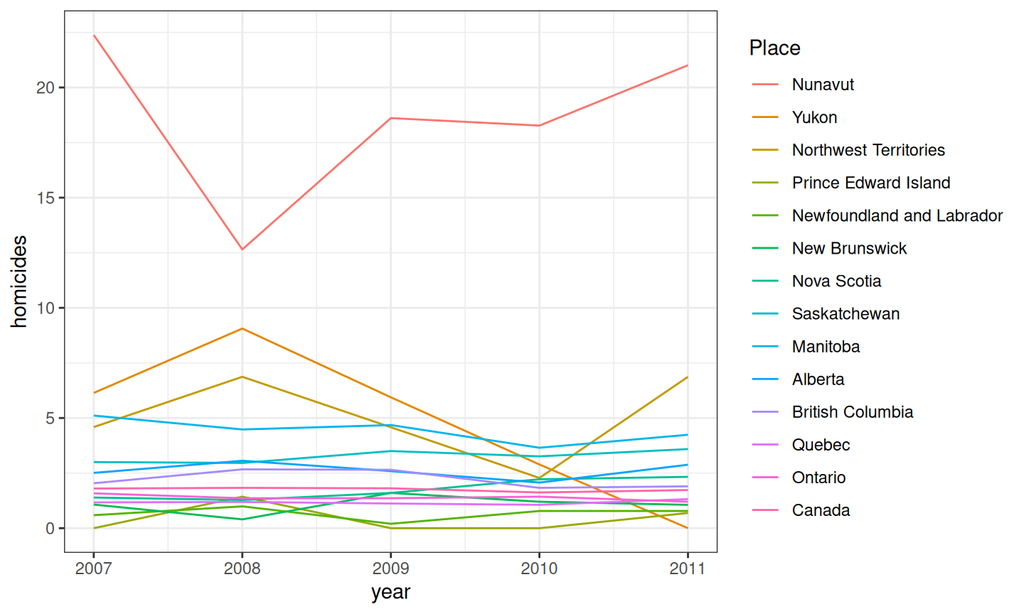

```r
print(p1+geom_line())
```

We could add both lines and points:

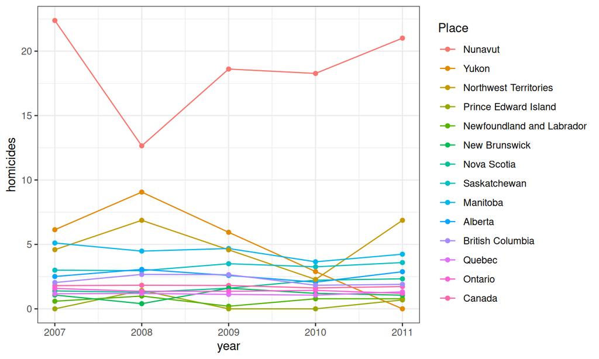

```r
print(p1+geom_line() +geom_point())
```

Might be better on a log scale, with a sensible y-axis label:

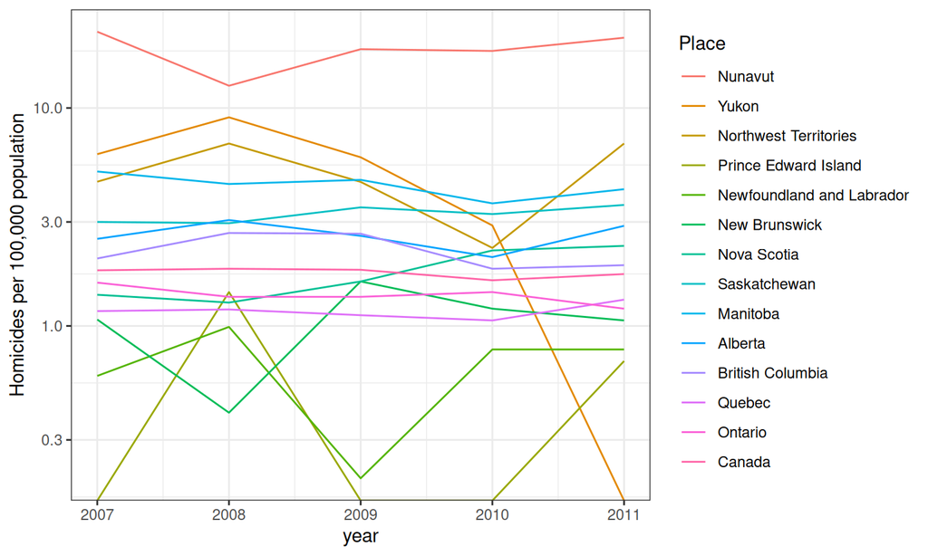

```r
p1L <- (p1
    + geom_line()
    + scale_y_log10()
    + labs(y="Homicides per 100,000 population")
)
print(p1L)
```

(Zero values get squashed against the lower axis)

Maybe we don’t care about time at all:

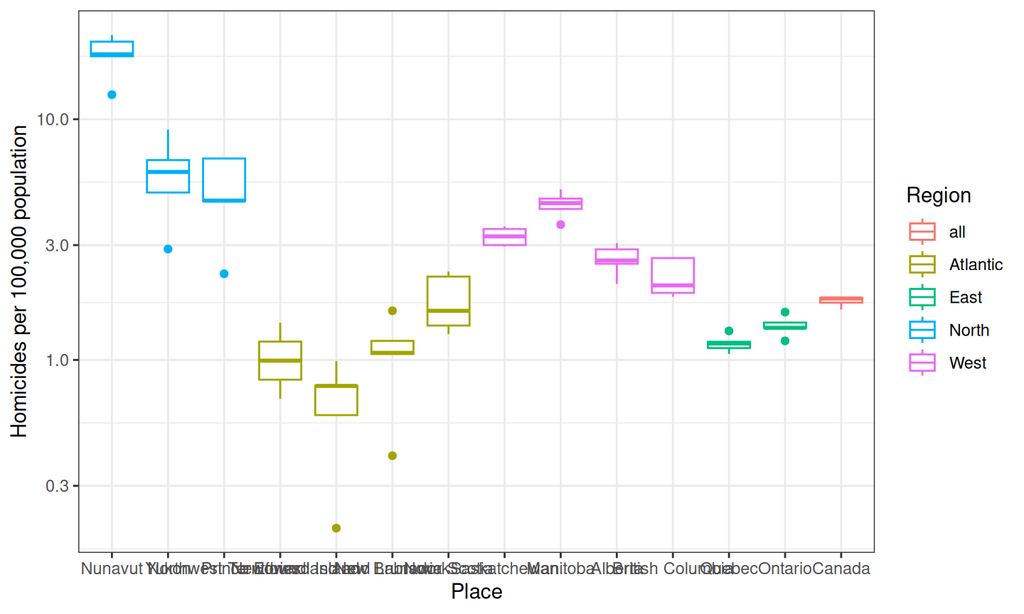

```r
b1 <- (ggplot(mdat,aes(x=Place,y=homicides,
                       colour=Region))
    + geom_boxplot(outlier.colour=NULL)  ## set outlier points to same colour as boxes
    + scale_y_log10()
    + labs(y="Homicides per 100,000 population")
)
print(b1)
```

The x-axis tick labels overlap enough to be unreadable (unless we resize the plot to be ridiculously long and narrow).

We could rotate them 90 degrees to be vertical:

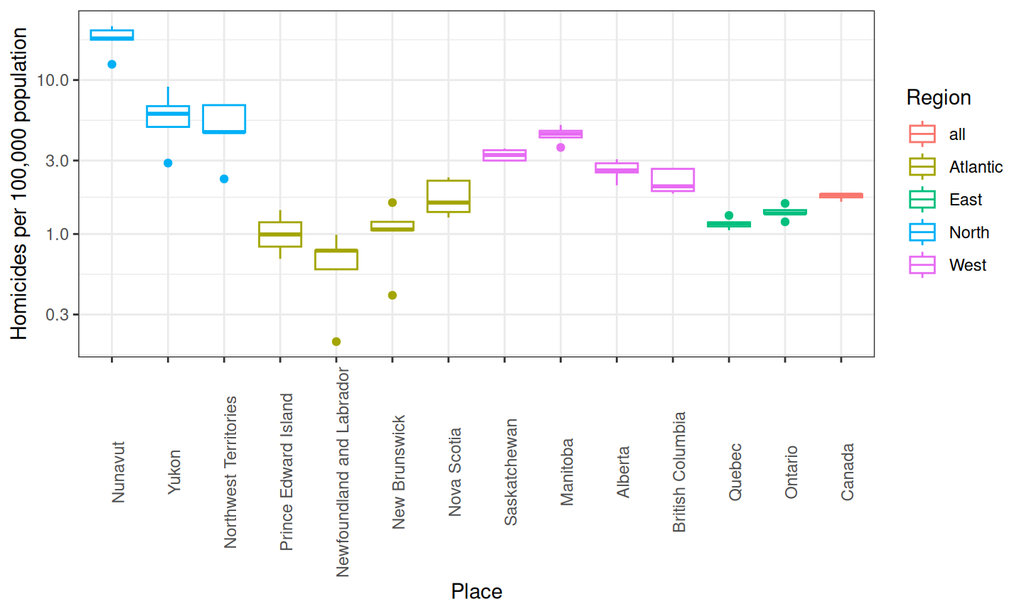

```r
b1_vertlabels <- b1+theme(axis.text.x=element_text(angle=90))
print(b1_vertlabels)
```

In general if you want to tweak a `ggplot` plot, Google it or search the [ggplot theme documentation](https://ggplot2.tidyverse.org/reference/theme.html) or the [ggplot cheat sheet](https://www.rstudio.com/wp-content/uploads/2015/03/ggplot2-cheatsheet.pdf) for more information …

Rotating the whole plot is less familiar, but arguably better. Here I’m also (1) changing the colour palette and (2) changing the order of the `Place` variable, using `%+%` to substitute a different set of data into an existing plot:

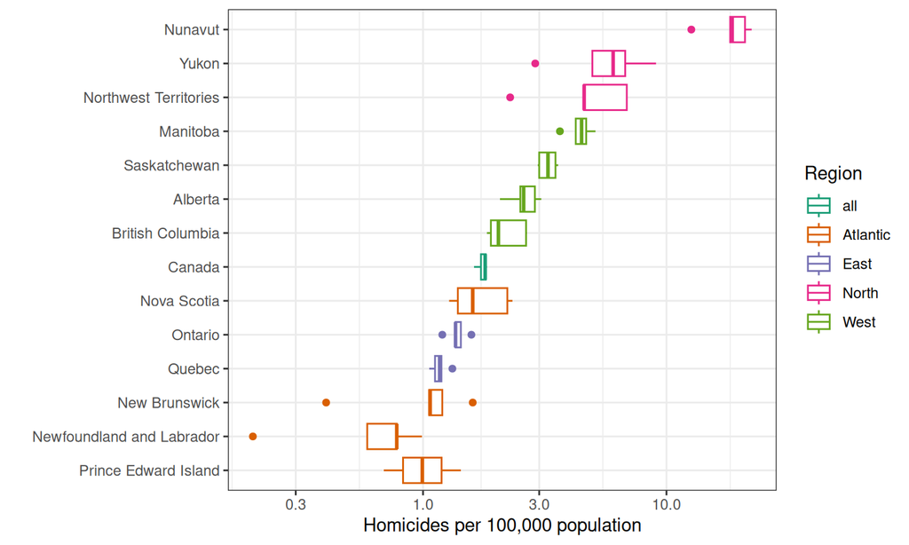

```r
mdat_sort <- mdat %>% mutate(across(Place,~forcats::fct_reorder(.,homicides)))
print(b1
      %+% mdat_sort  ## substitute sorted data
      + coord_flip()      ## rotate entire plot
      + xlab("")          ## x-label redundant
      + scale_colour_brewer(palette="Dark2") ## change palette
      )
```

Maybe we want to make our line graph less busy:

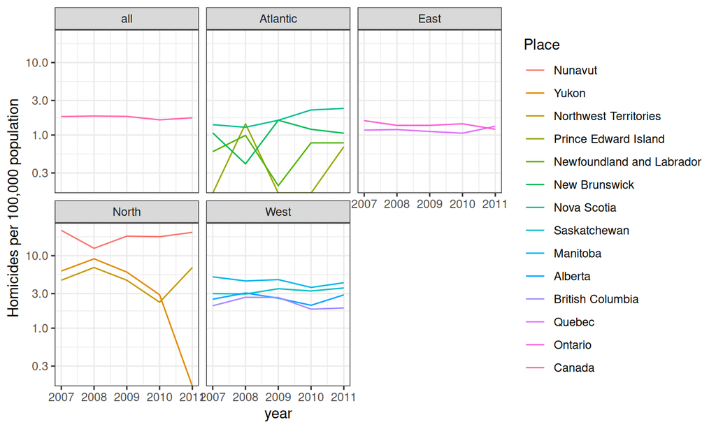

```r
print(p1L+facet_wrap(~Region))
```

We could also code population size by line width:

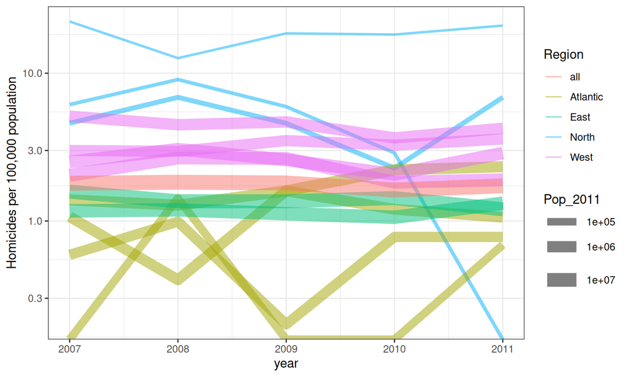

```r
p2 <- (ggplot(mdat,
             aes(year,homicides,colour=Region,size=Pop_2011,
                 group=Place))
    + geom_line(alpha=0.5)
    + scale_y_log10()
    + scale_size_continuous(trans="log10")
    + labs(y="Homicides per 100,000 population")
)
print(p2)
```

Using the [directlabels](http://directlabels.r-forge.r-project.org/) package:

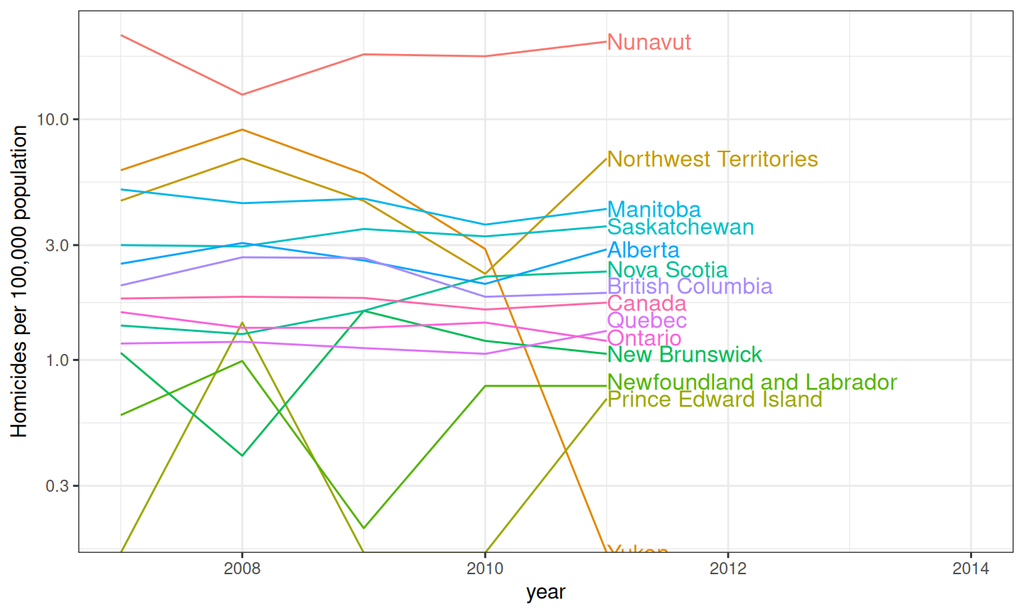

```r
library(directlabels)
last.bumpup <- list("last.points","bumpup")
print(p1L
    + expand_limits(x=2014)  ## add a little more space
    + geom_dl(aes(label=Place), method="last.bumpup")
    + theme(legend.position="none")  ## don't need the legend any more
)
```

We’d have to work a little harder to avoid clipping the “Yukon” label …